# Exam 2

You will submit this exam as a hardcopy Rmarkdown file (printed and stapled) to me by the end of class on May 2, 2021. Then email me your .Rmd file to docs4class@gmail.com.

#### Functions

1. Create a function called GPA_analysis. For this function, when you submit a GPA, the function should return whether or not this qualifies for honors based on the criteria below. Create the function and show that it works on various values.
- Cum laude: 3.5-3.7 GPA.
- Magna cum laude: 3.8-3.9 GPA.
- Summa cum laude: >3.9-4.0 GPA.
2. a)Create a function called Gerald that uses a single variable named S. The function should replace S with the square of S and repeat this process until S is either greater than 10^15 or less than 10^-15. b) Try this too once you get part a): The function should return a value Q containing the number of times S was squared during this process.

Examples:

- If S = 100, Q =3 (S equals 10^16 after the third square).
- If S = 0.1, Q=4 (S equals 10^-16 after the fourth square).
- If S = 3, Q =5 (S equals 1.853 x 10^15 after the fifth square).

#### Relational data, lubridate and wrangling using the `nycflights13` pacakge and datasets

3. What was the most common plane model to fly out of NYC in October with how many flights?
4. How many planes (tailnum) only flew one route (flight) but flew that route more than 10 times?
5. Which scheduled departure hour (use the “hour” column) had the largest proportion of flights delayed (dep_delay) longer than 5 min?
6. For all Alaska Air flights, show a plot (like the one below) showing the relationship exists between dep_delay and arr_delay.

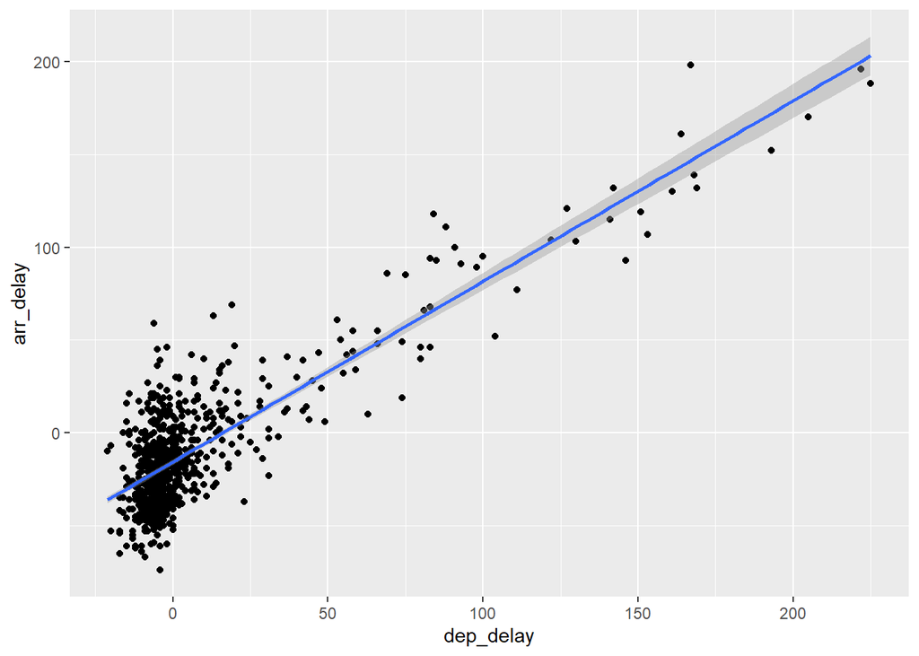

7. What day of the week saw the most flights?
8. What was the average number of seats and engines on the plains that left from NYC on July 4?

#### Trees and models

9. Use the `Boston` dataset from the `MASS` package to use random forests, pruning, boosting, and bagging. `Boston` gives housing values and other statistics in each of 506 suburbs of Boston based on a 1970 census. After loading the `MASS` package `?Boston` will give you great details about the data. Build at least two models predicting `medv` — which is the median value of owner-occupied homes in $1000s — one model being a random forest and another of your choosing. Which is better? Which variables are most important in predicting `medv`?
10. Draw some conclusions and interpretations from #9 as though you are providing insight to your boss who works for Zillow and wants to know what characteristics drive home values.